# ESS 330: Lab 6 - Machine Learning in Hydrology

```r
#Building the recipe

rec <- recipe(logQmean ~ aridity + p_mean, data = camels_train) %>%
  step_log(all_predictors()) %>%
  step_interact(terms = ~ aridity:p_mean) |>
  step_naomit(all_predictors(), all_outcomes())
```

```r
#Calling the data to a linear model

baked_data <- prep(rec, camels_train) |>
  bake(new_data = NULL)

lm_base <- lm(logQmean ~ aridity * p_mean, data = baked_data)

summary(lm_base)
```

```
Call:
lm(formula = logQmean ~ aridity * p_mean, data = baked_data)

Residuals:
     Min       1Q   Median       3Q      Max
-2.91162 -0.21601 -0.00716  0.21230  2.85706

Coefficients:
               Estimate Std. Error t value Pr(>|t|)
(Intercept)    -1.77586    0.16365 -10.852  < 2e-16 ***
aridity        -0.88397    0.16145  -5.475 6.75e-08 ***
p_mean          1.48438    0.15511   9.570  < 2e-16 ***
aridity:p_mean  0.10484    0.07198   1.457    0.146
---
Signif. codes:  0 '***' 0.001 '**' 0.01 '*' 0.05 '.' 0.1 ' ' 1

Residual standard error: 0.5696 on 531 degrees of freedom
Multiple R-squared:  0.7697,    Adjusted R-squared:  0.7684
F-statistic: 591.6 on 3 and 531 DF,  p-value: < 2.2e-16
```

```r
# Sanity CHECK!

summary(lm(logQmean ~ aridity + p_mean + aridity_x_p_mean, data = baked_data))
```

```
Call:
lm(formula = logQmean ~ aridity + p_mean + aridity_x_p_mean,
    data = baked_data)

Residuals:
     Min       1Q   Median       3Q      Max
-2.91162 -0.21601 -0.00716  0.21230  2.85706

Coefficients:
                 Estimate Std. Error t value Pr(>|t|)
(Intercept)      -1.77586    0.16365 -10.852  < 2e-16 ***
aridity          -0.88397    0.16145  -5.475 6.75e-08 ***
p_mean            1.48438    0.15511   9.570  < 2e-16 ***
aridity_x_p_mean  0.10484    0.07198   1.457    0.146
---
Signif. codes:  0 '***' 0.001 '**' 0.01 '*' 0.05 '.' 0.1 ' ' 1

Residual standard error: 0.5696 on 531 degrees of freedom
Multiple R-squared:  0.7697,    Adjusted R-squared:  0.7684
F-statistic: 591.6 on 3 and 531 DF,  p-value: < 2.2e-16
```

PASSED! BUT - now we test to see if our trained model and need to validate the tested data!

```r
# It's times to prep, bake, and predict:


test_data <- bake(prep(rec), new_data = camels_test)

test_data$lm_pred <- predict(lm_base, newdata = test_data)
```

Model Evaluation: Statistical and Visual

```r
metrics(test_data, truth = logQmean, estimate = lm_pred)
```

```
# A tibble: 3 × 3
  .metric .estimator .estimate
  <chr>   <chr>          <dbl>
1 rmse    standard       0.583
2 rsq     standard       0.742
3 mae     standard       0.390
```

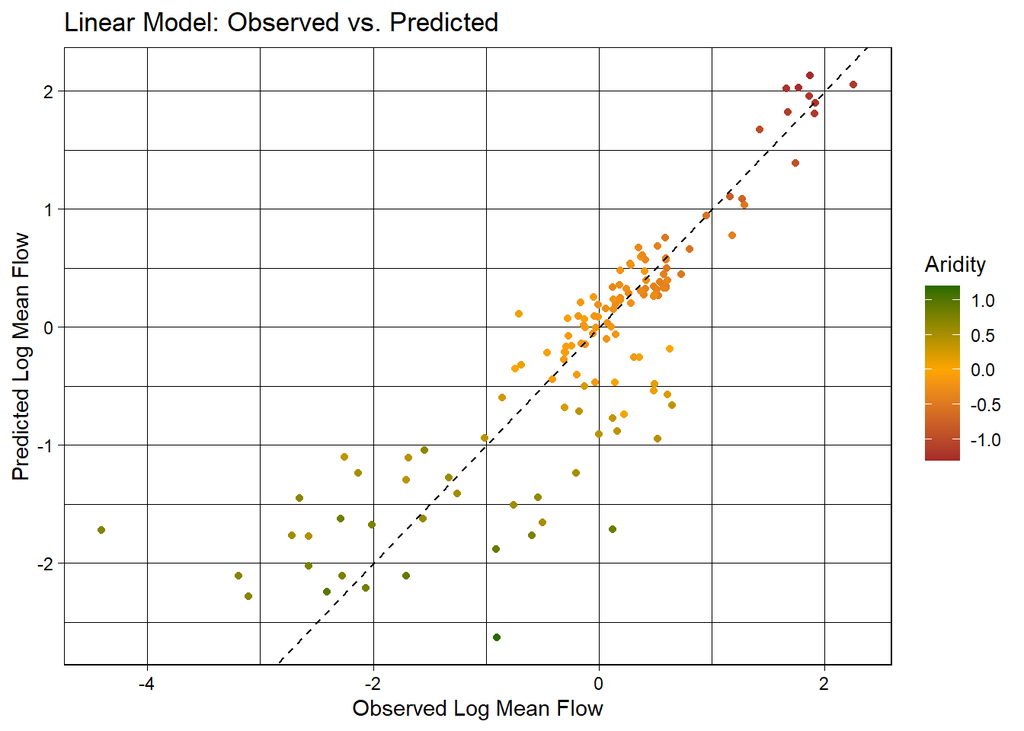

```r
ggplot(test_data, aes(x = logQmean, y = lm_pred, color = aridity)) +
  scale_color_gradient2(low = "brown", mid = "orange", high = "darkgreen") +
  geom_point() +
  geom_abline(linetype = 2) +
  theme_linedraw() +
  labs(title = "Linear Model: Observed vs. Predicted",
       x = "Observed Log Mean Flow",
       y = "Predicted Log Mean Flow",
       color = "Aridity")
```

#### **Using and workflow Instead**

```r
# Defining a model:
lm_model <- linear_reg() %>%
  set_engine('lm') %>%
  set_mode("regression")

#Instantiate the workflow:
lm_wf <- workflow() %>%
  add_recipe(rec) %>%
  add_model(lm_model) %>%
  fit(data = camels_train)

summary(extract_fit_engine(lm_wf))$coefficients
```

```
                   Estimate Std. Error    t value     Pr(>|t|)
(Intercept)      -1.7758557 0.16364755 -10.851710 6.463654e-25
aridity          -0.8839738 0.16144589  -5.475357 6.745512e-08
p_mean            1.4843771 0.15511117   9.569762 4.022500e-20
aridity_x_p_mean  0.1048449 0.07198145   1.456555 1.458304e-01
```

Making Predictions

```r
#NOW WE USE AUGMENT!

lm_data <- augment(lm_wf, new_data = camels_test)

dim(lm_data)
```

```
[1] 135  61
```

Model Evaluation

```r
metrics(lm_data, truth = logQmean, estimate = .pred)
```

```
# A tibble: 3 × 3
  .metric .estimator .estimate
  <chr>   <chr>          <dbl>
1 rmse    standard       0.583
2 rsq     standard       0.742
3 mae     standard       0.390
```

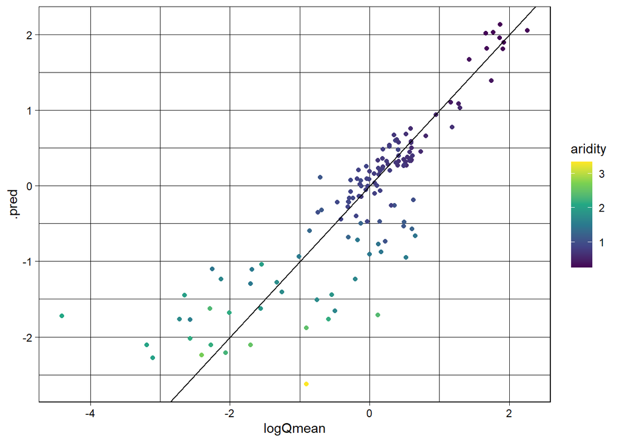

```r
ggplot(lm_data, aes(x = logQmean, y = .pred, color = aridity)) +
  scale_color_viridis_c() +
  geom_point() +
  geom_abline() +
  theme_linedraw()
```

SWITCHING IT UP!

```r
# Using the Random Forest Model!
library(baguette)

rf_model <- rand_forest() %>%
  set_engine("ranger", importance = "impurity") %>%
  set_mode("regression")

rf_wf <- workflow() %>%
  add_recipe(rec) %>%
  add_model(rf_model) %>%
  fit(data = camels_train)
```

```r
# Making Predictions:

rf_data <- augment(rf_wf, new_data = camels_test)
dim(rf_data)
```

```
[1] 135  60
```

```r
# Model Evaluating:

metrics(rf_data, truth = logQmean, estimate = .pred)
```

```
# A tibble: 3 × 3
  .metric .estimator .estimate
  <chr>   <chr>          <dbl>
1 rmse    standard       0.596
2 rsq     standard       0.733
3 mae     standard       0.370
```

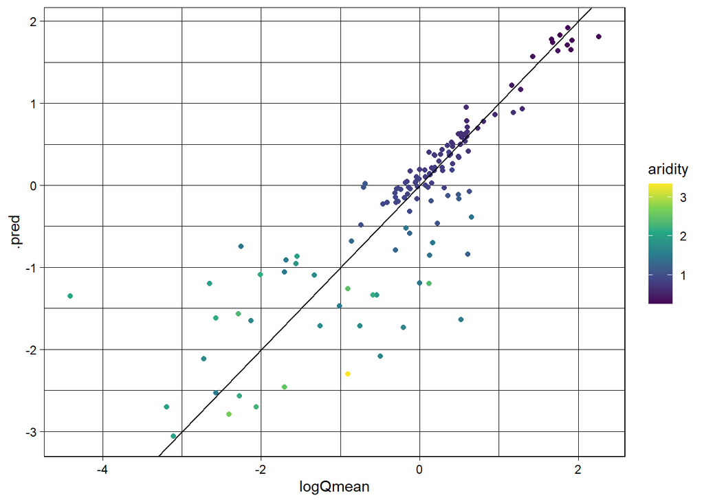

```r
#Plotting:
ggplot(rf_data, aes(x = logQmean, y = .pred, color = aridity)) +
  scale_color_viridis_c() +
  geom_point() +
  geom_abline() +
  theme_linedraw()
```

**WORKFLOW SET APPROACH!**

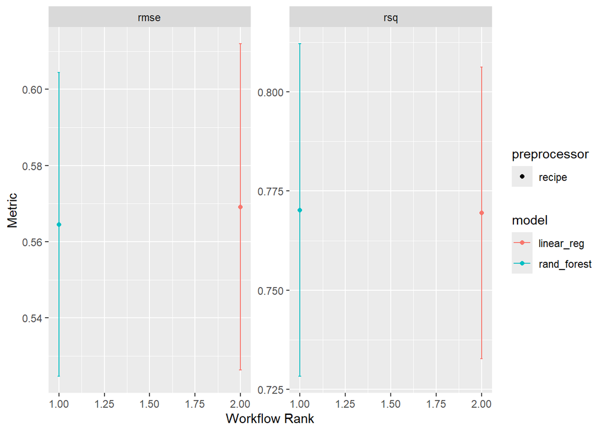

```r
wf <- workflow_set(list(rec), list(lm_model, rf_model)) %>%
  workflow_map('fit_resamples', resamples = camels_cv)
autoplot(wf)
```

```r
rank_results(wf, rank_metric = "rsq", select_best = TRUE)
```

```
# A tibble: 4 × 9
  wflow_id          .config .metric  mean std_err     n preprocessor model  rank
  <chr>             <chr>   <chr>   <dbl>   <dbl> <int> <chr>        <chr> <int>
1 recipe_rand_fore… Prepro… rmse    0.565  0.0243    10 recipe       rand…     1
2 recipe_rand_fore… Prepro… rsq     0.770  0.0255    10 recipe       rand…     1
3 recipe_linear_reg Prepro… rmse    0.569  0.0260    10 recipe       line…     2
4 recipe_linear_reg Prepro… rsq     0.770  0.0223    10 recipe       line…     2
```

## **Question 3: Building XGBOOST and Neural Networks**

```r
# XG Boost Model

b_model <- boost_tree() %>%
  set_engine("xgboost") %>%
  set_mode("regression")

b_wf <- workflow() %>%
  add_recipe(rec) %>%
  add_model(b_model) %>%
  fit(data = camels_train)
```

```r
b_data <- augment(b_wf, new_data = camels_test)
dim(b_data)
```

```
[1] 135  60
```

```r
metrics(b_data, truth = logQmean, estimate = .pred)
```

```
# A tibble: 3 × 3
  .metric .estimator .estimate
  <chr>   <chr>          <dbl>
1 rmse    standard       0.631
2 rsq     standard       0.702
3 mae     standard       0.397
```

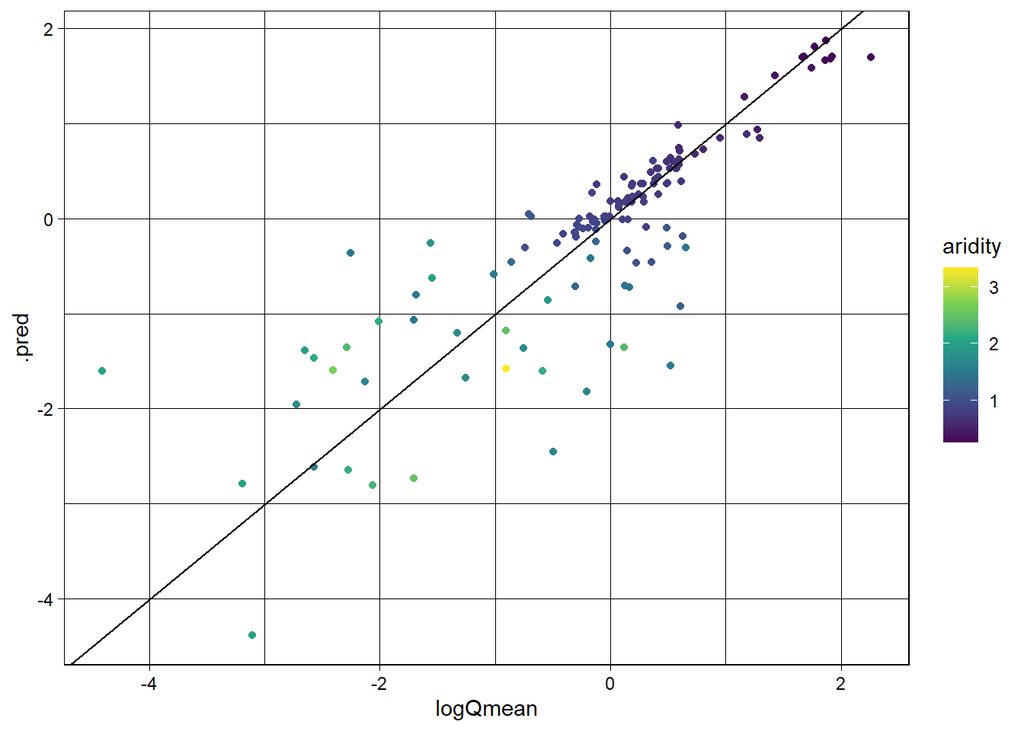

```r
# Checking metrics:
ggplot(b_data, aes(x = logQmean, y = .pred, colour = aridity)) +
  scale_color_viridis_c() +
  geom_point() +
  geom_abline() +
  theme_linedraw()
```

```r
# Neural Network time:

nn_model <- mlp(hidden_units = 5, penalty = 0.01) %>%
  set_engine("nnet") %>%
  set_mode("regression")

nn_wf <- workflow() %>%
  add_recipe(rec) %>%
  add_model(nn_model) %>%
  fit(data = camels_train)

nn_data <- augment(nn_wf, new_data = camels_test)
dim(nn_data)
```

```
[1] 135  61
```

```r
metrics(nn_data, truth = logQmean, estimate = .pred)
```

```
# A tibble: 3 × 3
  .metric .estimator .estimate
  <chr>   <chr>          <dbl>
1 rmse    standard       0.553
2 rsq     standard       0.767
3 mae     standard       0.350
```

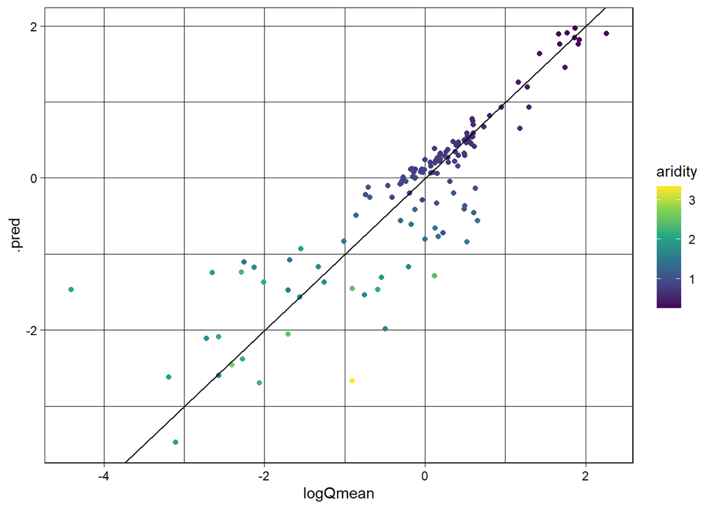

```r
ggplot(nn_data, aes(x = logQmean, y = .pred, colour = aridity)) +
  scale_color_viridis_c() +
  geom_point() +
  geom_abline() +
  theme_linedraw()
```

**Combining all (linear regression, random Forest, XG Boost, and Neural Network Models)**

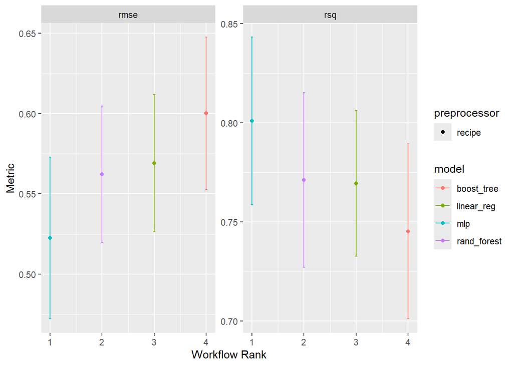

```r
wf <- workflow_set(list(rec), list(lm_model, rf_model, b_model, nn_model)) %>%
  workflow_map('fit_resamples', resamples = camels_cv)
autoplot(wf)
```

```r
rank_results(wf, rank_metric = "rsq", select_best = TRUE)
```

```
# A tibble: 8 × 9
  wflow_id          .config .metric  mean std_err     n preprocessor model  rank
  <chr>             <chr>   <chr>   <dbl>   <dbl> <int> <chr>        <chr> <int>
1 recipe_mlp        Prepro… rmse    0.523  0.0307    10 recipe       mlp       1
2 recipe_mlp        Prepro… rsq     0.801  0.0257    10 recipe       mlp       1
3 recipe_rand_fore… Prepro… rmse    0.562  0.0258    10 recipe       rand…     2
4 recipe_rand_fore… Prepro… rsq     0.771  0.0268    10 recipe       rand…     2
5 recipe_linear_reg Prepro… rmse    0.569  0.0260    10 recipe       line…     3
6 recipe_linear_reg Prepro… rsq     0.770  0.0223    10 recipe       line…     3
7 recipe_boost_tree Prepro… rmse    0.600  0.0289    10 recipe       boos…     4
8 recipe_boost_tree Prepro… rsq     0.745  0.0268    10 recipe       boos…     4
```

From these tests, we can understand that the neural network and mlp model are performing better for rmsq and rsq in the linear model than the linear and random forests models.

We will move forward with the neural network model to understand this relationship between Observed Log Mean Flow, Predicted Log Mean Flow, and Aridity.

## **BUILDING MY OWN TEST/TRAIN MODEL**

streamflow predictions

```r
# Data Splitting

set.seed(123)

camels <- camels |>
  mutate(logQmean = log(q_mean))

camels_split <- initial_split(camels, prop = 0.75)

camels_train <- training(camels_split)

camels_test <- testing(camels_split)

camels_cv <- vfold_cv(camels_train, v = 10)
```

```r
# Recipe

rec <- recipe(logQmean ~ p_mean + max_water_content, data = camels_train) %>%
  step_log(all_predictors()) %>%
  step_interact(terms = ~ p_mean:max_water_content) |>
  step_naomit(all_predictors(), all_outcomes())
```

I chose to look at the relationship the precipitation mean has with the maximum water content of soil profiles. This will help us understand if the discharge mean of streamflow as it is related to the maximum water content that can be retained before becoming discharge. Seen below:

```r
baked_data <- prep(rec, camels_train) |>
  bake(new_data = NULL)

lm_base <- lm(logQmean ~ p_mean * max_water_content, data = baked_data)

summary(lm_base)
```

```
Call:
lm(formula = logQmean ~ p_mean * max_water_content, data = baked_data)

Residuals:
     Min       1Q   Median       3Q      Max
-2.70495 -0.31108  0.04349  0.28573  2.06245

Coefficients:
                         Estimate Std. Error t value Pr(>|t|)
(Intercept)               -3.2241     0.1451 -22.214  < 2e-16 ***
p_mean                     2.6732     0.1341  19.931  < 2e-16 ***
max_water_content         -0.5949     0.1352  -4.400 1.33e-05 ***
p_mean:max_water_content   0.3081     0.1399   2.203   0.0281 *
---
Signif. codes:  0 '***' 0.001 '**' 0.01 '*' 0.05 '.' 0.1 ' ' 1

Residual standard error: 0.5775 on 498 degrees of freedom
Multiple R-squared:  0.7668,    Adjusted R-squared:  0.7654
F-statistic: 545.9 on 3 and 498 DF,  p-value: < 2.2e-16
```

```r
test_data <- bake(prep(rec), new_data = camels_test)

test_data$lm_pred <- predict(lm_base, newdata = test_data)

metrics(test_data, truth = logQmean, estimate = lm_pred)
```

```
# A tibble: 3 × 3
  .metric .estimator .estimate
  <chr>   <chr>          <dbl>
1 rmse    standard       0.572
2 rsq     standard       0.746
3 mae     standard       0.427
```

```r
# Defining Random Forest Model

library(baguette)

rf_model <- rand_forest() %>%
  set_engine("ranger", importance = "impurity") %>%
  set_mode("regression")


#Creating and Adding it to the workflow set
rf_wf <- workflow() %>%
  add_recipe(rec) %>%
  add_model(rf_model) %>%
  fit(data = camels_train)
```

```r
rf_data <- augment(rf_wf, new_data = camels_test)
dim(rf_data)
```

```
[1] 168  60
```

```r
metrics(rf_data, truth = logQmean, estimate = .pred)
```

```
# A tibble: 3 × 3
  .metric .estimator .estimate
  <chr>   <chr>          <dbl>
1 rmse    standard       0.600
2 rsq     standard       0.720
3 mae     standard       0.399
```

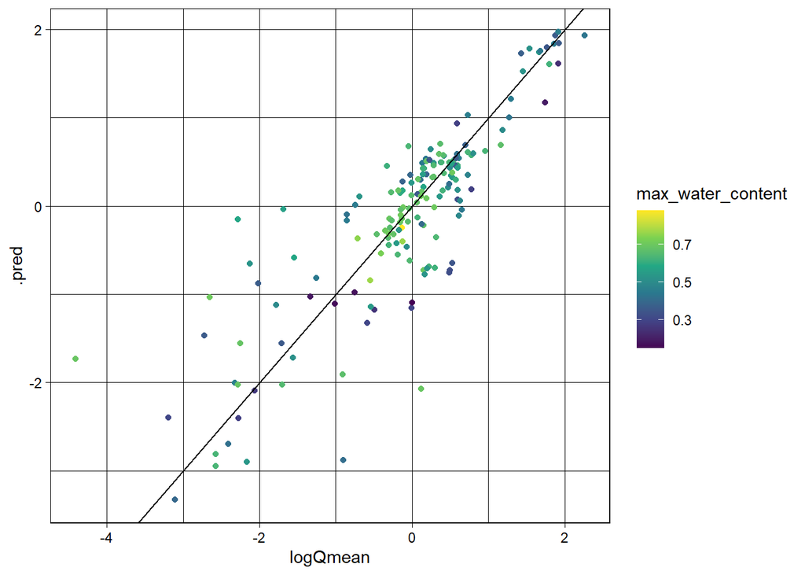

```r
ggplot(rf_data, aes(x = logQmean, y = .pred, color = max_water_content)) +
  scale_color_viridis_c() +
  geom_point() +
  geom_abline() +
  theme_linedraw()
```

```r
# Defining a Linear Regression Model
lm_model <- linear_reg() %>%
  set_engine('lm') %>%
  set_mode("regression")

#Instantiate the workflow:
lm_wf <- workflow() %>%
  add_recipe(rec) %>%
  add_model(lm_model) %>%
  fit(data = camels_train)

summary(extract_fit_engine(lm_wf))$coefficients
```

```
                             Estimate Std. Error    t value     Pr(>|t|)
(Intercept)                -3.2240978  0.1451356 -22.214387 1.734810e-76
p_mean                      2.6732285  0.1341254  19.930812 2.022897e-65
max_water_content          -0.5949414  0.1352244  -4.399662 1.326996e-05
p_mean_x_max_water_content  0.3080732  0.1398610   2.202709 2.807261e-02
```

```r
lm_data <- augment(lm_wf, new_data = camels_test)

dim(lm_data)
```

```
[1] 168  61
```

```r
metrics(lm_data, truth = logQmean, estimate = .pred)
```

```
# A tibble: 3 × 3
  .metric .estimator .estimate
  <chr>   <chr>          <dbl>
1 rmse    standard       0.572
2 rsq     standard       0.746
3 mae     standard       0.427
```

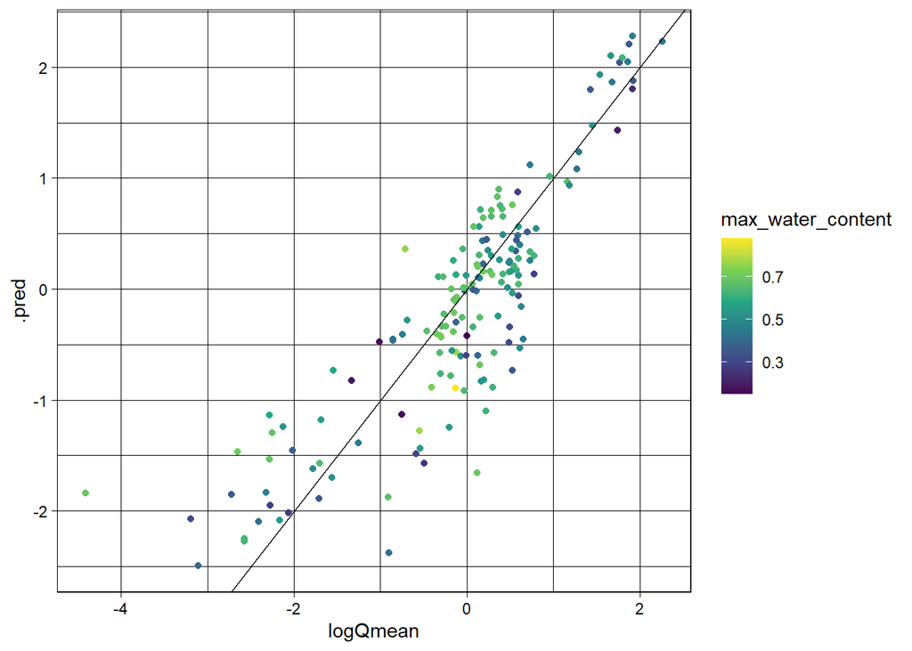

```r
ggplot(lm_data, aes(x = logQmean, y = .pred, color = max_water_content)) +
  scale_color_viridis_c() +
  geom_point() +
  geom_abline() +
  theme_linedraw()
```

```r
# Defining a XG Boost Model

b_model <- boost_tree() %>%
  set_engine('xgboost') %>%
  set_mode("regression")

b_wf <- workflow() %>%
  add_recipe(rec) %>%
  add_model(b_model) %>%
  fit(data = camels_train)
```

```r
b_data <- augment(b_wf, new_data = camels_test)
dim(b_data)
```

```
[1] 168  60
```

```r
metrics(b_data, truth = logQmean, estimate = .pred)
```

```
# A tibble: 3 × 3
  .metric .estimator .estimate
  <chr>   <chr>          <dbl>
1 rmse    standard       0.671
2 rsq     standard       0.662
3 mae     standard       0.425
```

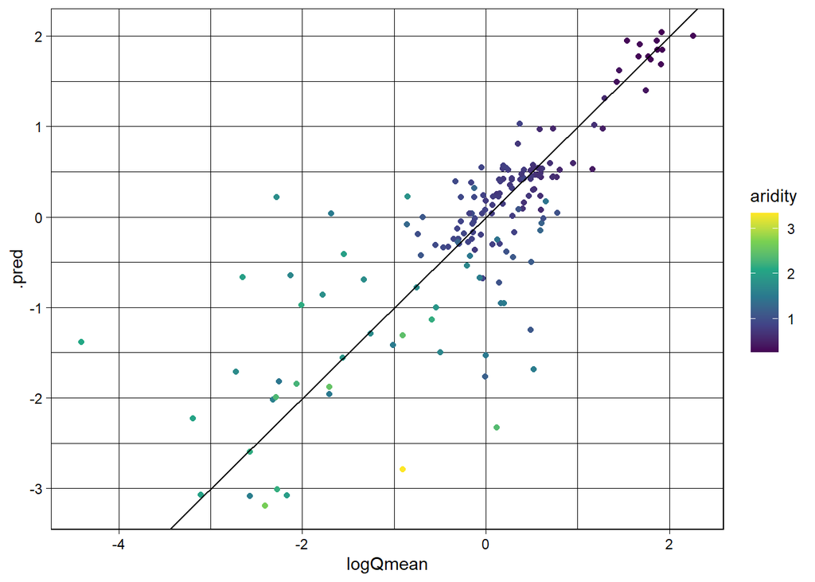

```r
# Checking metrics:
ggplot(b_data, aes(x = logQmean, y = .pred, colour = aridity)) +
  scale_color_viridis_c() +
  geom_point() +
  geom_abline() +
  theme_linedraw()
```

**workflow set and Evaluating**

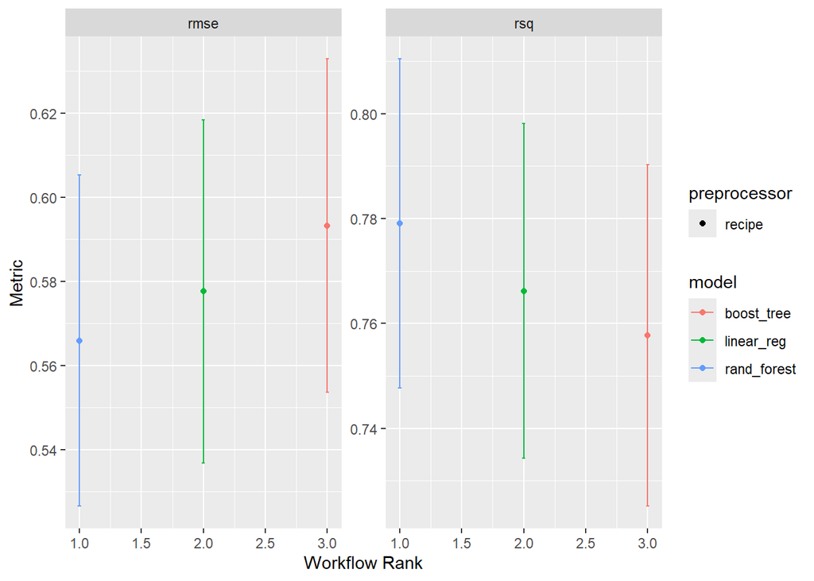

```r
wf_obj <- workflow_set(list(rec), list(rf_model, lm_model, b_model)) %>%
  workflow_map('fit_resamples', resamples = camels_cv)

autoplot(wf_obj)
```

```r
rank_results(wf_obj, rank_metric = "rsq", select_best = TRUE)
```

```
# A tibble: 6 × 9
  wflow_id          .config .metric  mean std_err     n preprocessor model  rank
  <chr>             <chr>   <chr>   <dbl>   <dbl> <int> <chr>        <chr> <int>
1 recipe_rand_fore… Prepro… rmse    0.566  0.0239    10 recipe       rand…     1
2 recipe_rand_fore… Prepro… rsq     0.779  0.0191    10 recipe       rand…     1
3 recipe_linear_reg Prepro… rmse    0.578  0.0248    10 recipe       line…     2
4 recipe_linear_reg Prepro… rsq     0.766  0.0194    10 recipe       line…     2
5 recipe_boost_tree Prepro… rmse    0.593  0.0241    10 recipe       boos…     3
6 recipe_boost_tree Prepro… rsq     0.758  0.0198    10 recipe       boos…     3
```

For understanding the relationship max water content of soils and precipitation means as they affect discharge mean rates, we should use the random forest model to continue this testing and training of the camels data. Based on the ranking and autoplot the random forest model performs better for understanding the predicted mean streamflow.

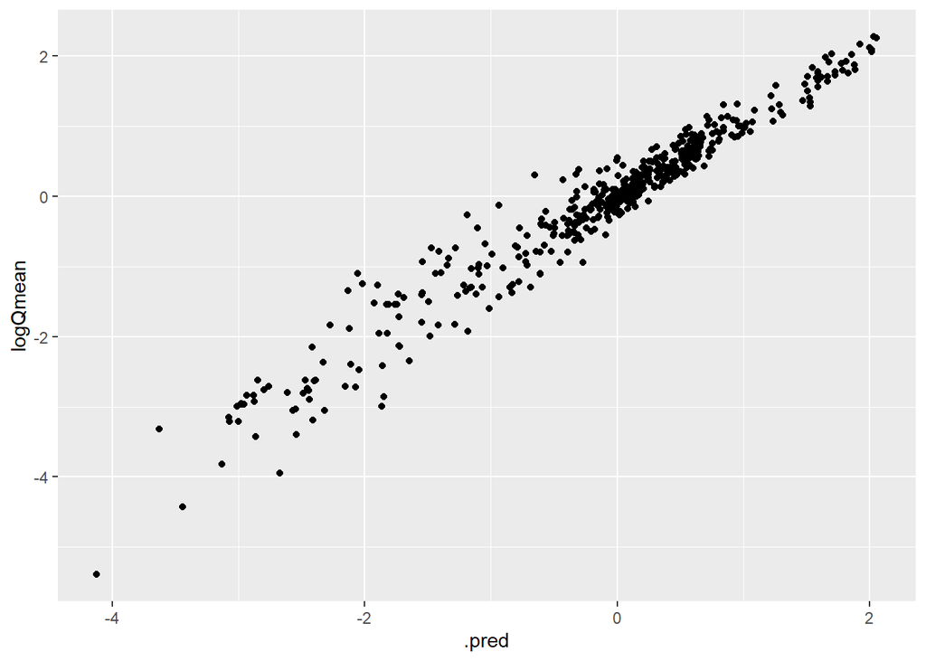

```r
# Extract and Evaluate

rf_fit = workflow() |>
  add_recipe(rec) |>
  add_model(rf_model) |>
  fit(camels_train)

a = augment(rf_fit, new_data = camels_train)

ggplot(a, aes(x = .pred, y = logQmean)) +
  geom_point()
```

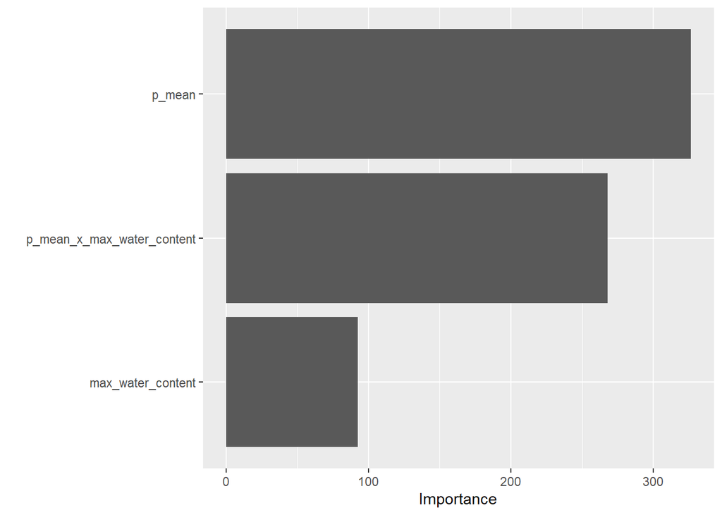

```r
vip::vip(rf_fit)
```

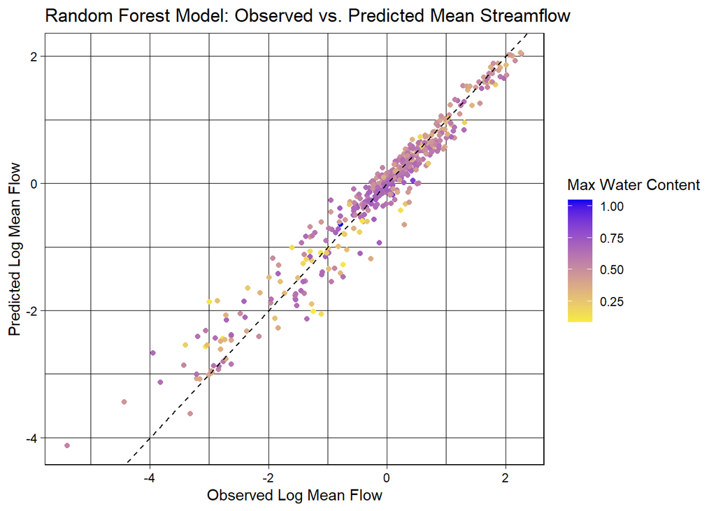

```r
ggplot(a, aes(x = logQmean, y = .pred, color = max_water_content)) +
  scale_color_gradient2(low = "red", mid = "yellow", high = "blue2") +
  geom_point() +
  geom_abline(linetype = 2) +
  theme_linedraw() +
  labs(title = "Random Forest Model: Observed vs. Predicted Mean Streamflow",
       x = "Observed Log Mean Flow",
       y = "Predicted Log Mean Flow",
       color = "Max Water Content")
```